# Part I - (Exploration of Prosper Loan Dataset)

## Introduction

> > This Dataset contains the records of 15198 loans listings with lot of releted variables including loan amount, borrower rate (or interest rate), current loan status, borrower state, and many others. This Data can be used to make lot of informed decisions and also finding interesting insights.

## Preliminary Wrangling

```python
# import all packages and set plots to be embedded inline
import numpy as np
import pandas as pd
import matplotlib.pyplot as plt
import seaborn as sb

%matplotlib inline
```

```python
loan=pd.read_csv('prosperLoanData.csv',engine='python',encoding='utf-8', error_bad_lines=False)
```

```
Skipping line 15200: unexpected end of data
```

```python
loan.head()
```

|  | ListingKey | ListingNumber | ListingCreationDate | CreditGrade | Term | LoanStatus | ClosedDate | BorrowerAPR | BorrowerRate | LenderYield | ... | LP_ServiceFees | LP_CollectionFees | LP_GrossPrincipalLoss | LP_NetPrincipalLoss | LP_NonPrincipalRecoverypayments | PercentFunded | Recommendations | InvestmentFromFriendsCount | InvestmentFromFriendsAmount | Investors |
| --- | --- | --- | --- | --- | --- | --- | --- | --- | --- | --- | --- | --- | --- | --- | --- | --- | --- | --- | --- | --- | --- |
| 0 | 1021339766868145413AB3B | 193129 | 2007-08-26 19:09:29.263000000 | C | 36 | Completed | 2009-08-14 00:00:00 | 0.16516 | 0.1580 | 0.1380 | ... | -133.18 | 0.0 | 0.0 | 0.0 | 0.0 | 1.0 | 0 | 0 | 0.0 | 258 |
| 1 | 10273602499503308B223C1 | 1209647 | 2014-02-27 08:28:07.900000000 | NaN | 36 | Current | NaN | 0.12016 | 0.0920 | 0.0820 | ... | 0.00 | 0.0 | 0.0 | 0.0 | 0.0 | 1.0 | 0 | 0 | 0.0 | 1 |
| 2 | 0EE9337825851032864889A | 81716 | 2007-01-05 15:00:47.090000000 | HR | 36 | Completed | 2009-12-17 00:00:00 | 0.28269 | 0.2750 | 0.2400 | ... | -24.20 | 0.0 | 0.0 | 0.0 | 0.0 | 1.0 | 0 | 0 | 0.0 | 41 |
| 3 | 0EF5356002482715299901A | 658116 | 2012-10-22 11:02:35.010000000 | NaN | 36 | Current | NaN | 0.12528 | 0.0974 | 0.0874 | ... | -108.01 | 0.0 | 0.0 | 0.0 | 0.0 | 1.0 | 0 | 0 | 0.0 | 158 |
| 4 | 0F023589499656230C5E3E2 | 909464 | 2013-09-14 18:38:39.097000000 | NaN | 36 | Current | NaN | 0.24614 | 0.2085 | 0.1985 | ... | -60.27 | 0.0 | 0.0 | 0.0 | 0.0 | 1.0 | 0 | 0 | 0.0 | 20 |

5 rows × 81 columns

```python
loan.dtypes
```

```
ListingKey                              object
ListingNumber                            int64
ListingCreationDate                     object
CreditGrade                             object
Term                                     int64
LoanStatus                              object
ClosedDate                              object
BorrowerAPR                            float64
BorrowerRate                           float64
LenderYield                            float64
EstimatedEffectiveYield                float64
EstimatedLoss                          float64
EstimatedReturn                        float64
ProsperRating (numeric)                float64
ProsperRating (Alpha)                   object
ProsperScore                           float64
ListingCategory (numeric)                int64
BorrowerState                           object
Occupation                              object
EmploymentStatus                        object
EmploymentStatusDuration               float64
IsBorrowerHomeowner                       bool
CurrentlyInGroup                          bool
GroupKey                                object
DateCreditPulled                        object
CreditScoreRangeLower                  float64
CreditScoreRangeUpper                  float64
FirstRecordedCreditLine                 object
CurrentCreditLines                     float64
OpenCreditLines                        float64
                                        ...
TotalProsperLoans                      float64
TotalProsperPaymentsBilled             float64
OnTimeProsperPayments                  float64
ProsperPaymentsLessThanOneMonthLate    float64
ProsperPaymentsOneMonthPlusLate        float64
ProsperPrincipalBorrowed               float64
ProsperPrincipalOutstanding            float64
ScorexChangeAtTimeOfListing            float64
LoanCurrentDaysDelinquent                int64
LoanFirstDefaultedCycleNumber          float64
LoanMonthsSinceOrigination               int64
LoanNumber                               int64
LoanOriginalAmount                       int64
LoanOriginationDate                     object
LoanOriginationQuarter                  object
MemberKey                               object
MonthlyLoanPayment                     float64
LP_CustomerPayments                    float64
LP_CustomerPrincipalPayments           float64
LP_InterestandFees                     float64
LP_ServiceFees                         float64
LP_CollectionFees                      float64
LP_GrossPrincipalLoss                  float64
LP_NetPrincipalLoss                    float64
LP_NonPrincipalRecoverypayments        float64
PercentFunded                          float64
Recommendations                          int64
InvestmentFromFriendsCount               int64
InvestmentFromFriendsAmount            float64
Investors                                int64
Length: 81, dtype: object
```

```python
# checkin unique values of the Borrower states
loan.BorrowerState.unique()
```

```
array(['CO', 'GA', 'MN', 'NM', 'KS', 'CA', 'IL', 'MD', nan, 'AL', 'AZ',
       'VA', 'FL', 'PA', 'OR', 'MI', 'NY', 'LA', 'WI', 'OH', 'NC', 'WA',
       'NV', 'NJ', 'TX', 'AR', 'SC', 'DE', 'MO', 'NE', 'UT', 'DC', 'MA',
       'CT', 'IN', 'KY', 'OK', 'MS', 'WV', 'RI', 'TN', 'ID', 'MT', 'HI',
       'NH', 'VT', 'WY', 'ME', 'AK', 'IA', 'SD', 'ND'], dtype=object)
```

```python
loan.shape
```

```
(15198, 81)
```

```python
loan.describe()
```

|  | ListingNumber | Term | BorrowerAPR | BorrowerRate | LenderYield | EstimatedEffectiveYield | EstimatedLoss | EstimatedReturn | ProsperRating (numeric) | ProsperScore | ... | LP_ServiceFees | LP_CollectionFees | LP_GrossPrincipalLoss | LP_NetPrincipalLoss | LP_NonPrincipalRecoverypayments | PercentFunded | Recommendations | InvestmentFromFriendsCount | InvestmentFromFriendsAmount | Investors |
| --- | --- | --- | --- | --- | --- | --- | --- | --- | --- | --- | --- | --- | --- | --- | --- | --- | --- | --- | --- | --- | --- |
| count | 1.519800e+04 | 15198.000000 | 15196.000000 | 15198.000000 | 15198.000000 | 11298.000000 | 11298.000000 | 11298.000000 | 11298.000000 | 11298.000000 | ... | 15198.000000 | 15198.000000 | 15198.000000 | 15198.000000 | 15198.000000 | 15198.000000 | 15198.000000 | 15198.000000 | 15198.000000 | 15198.000000 |
| mean | 6.297236e+05 | 40.890644 | 0.218575 | 0.192489 | 0.182426 | 0.169119 | 0.080333 | 0.096180 | 4.072668 | 5.942291 | ... | -54.681028 | -15.351338 | 712.173466 | 692.438327 | 25.165580 | 0.998637 | 0.047177 | 0.023424 | 15.808831 | 80.075602 |
| std | 3.275490e+05 | 10.429559 | 0.080104 | 0.074579 | 0.074274 | 0.068103 | 0.046661 | 0.030295 | 1.660942 | 2.352159 | ... | 61.361288 | 135.874416 | 2403.321429 | 2377.431561 | 298.249539 | 0.017559 | 0.427794 | 0.324643 | 316.983574 | 103.605985 |
| min | 3.600000e+01 | 12.000000 | 0.016570 | 0.010000 | 0.001500 | -0.177300 | 0.004900 | -0.177300 | 1.000000 | 1.000000 | ... | -553.880000 | -9274.750000 | 0.000000 | -137.620000 | 0.000000 | 0.700500 | 0.000000 | 0.000000 | 0.000000 | 1.000000 |
| 25% | 3.995170e+05 | 36.000000 | 0.156290 | 0.134000 | 0.124500 | 0.118100 | 0.042400 | 0.074630 | 3.000000 | 4.000000 | ... | -73.035000 | 0.000000 | 0.000000 | 0.000000 | 0.000000 | 1.000000 | 0.000000 | 0.000000 | 0.000000 | 2.000000 |
| 50% | 6.029290e+05 | 36.000000 | 0.208080 | 0.182400 | 0.172400 | 0.161620 | 0.072400 | 0.091200 | 4.000000 | 6.000000 | ... | -33.780000 | 0.000000 | 0.000000 | 0.000000 | 0.000000 | 1.000000 | 0.000000 | 0.000000 | 0.000000 | 42.000000 |
| 75% | 8.986538e+05 | 36.000000 | 0.283240 | 0.250000 | 0.239900 | 0.224150 | 0.112000 | 0.116800 | 5.000000 | 8.000000 | ... | -13.350000 | 0.000000 | 0.000000 | 0.000000 | 0.000000 | 1.000000 | 0.000000 | 0.000000 | 0.000000 | 114.000000 |
| max | 1.255725e+06 | 60.000000 | 0.413550 | 0.400000 | 0.395000 | 0.319900 | 0.366000 | 0.257000 | 7.000000 | 11.000000 | ... | 9.810000 | 0.000000 | 25000.000000 | 25000.000000 | 21117.900000 | 1.004500 | 39.000000 | 33.000000 | 23699.520000 | 899.000000 |

8 rows × 61 columns

### What is the structure of your dataset?

> This Dataset contains the records of 15198 loans including loan amount, borrower rate (or interest rate), current loan status, borrower state, and many others.

### What is/are the main feature(s) of interest in your dataset?

> I am more interested on what are the features that affect the interest rate,so I will be spending more time basing my focus on finding the relationship between individual variables and also with the interest rate.

### What features in the dataset do you think will help support your investigation into your feature(s) of interest?

> I will base my focus more on features like occupation, BorrowerState and see if the state and occupation plays a role on interest given to a borrower.  
> I will be looking at the numerical features such as `LoanOriginalAmount`, `MonthlyLoanPayment` and `StatedMonthlyIncome`,`ProsperScore`,`Term` as they can play a significant role in interest decision.

## Univariate Exploration

```python
## Declaring the function to plot the count plots of catagorical variables, to see their distributions.
def plotCountplot(x, figsize=(12,8)):
    #plot size
    plt.figure(figsize=figsize)
    #plot color
    base_color = sb.color_palette()[0]
    #Countplot
    sb.countplot(data = loan, x = x,color = base_color);
    #xticks rotation
    plt.xticks(rotation=90)
    #xlabel
    plt.xlabel(x, weight = "bold", fontsize = 12)
    #ylabel
    plt.ylabel('Count',weight = "bold", fontsize = 12)
    #title
    plt.title('Distribution of '+x, weight = "bold", fontsize = 16)
    plt.show()
```

```
Text(0.5,1,'Interest rate distribution according to listings')
```

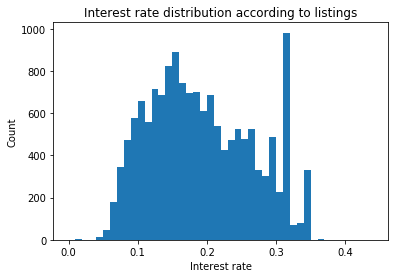

```python
## The distribution of the variable of interest
binsize=np.arange(0,loan['BorrowerRate'].max()+0.05,0.01)
plt.hist(data=loan,x='BorrowerRate',bins=binsize);
plt.xlabel('Interest rate')
plt.ylabel('Count')
plt.title('Interest rate distribution according to listings')
```

- There is a little bit of normal distribution with more interest rates data points towards the 0.1-0.2 range.

### 2. What is the distribution of listings on each state

```python
states_listings=loan.BorrowerState.value_counts()
```

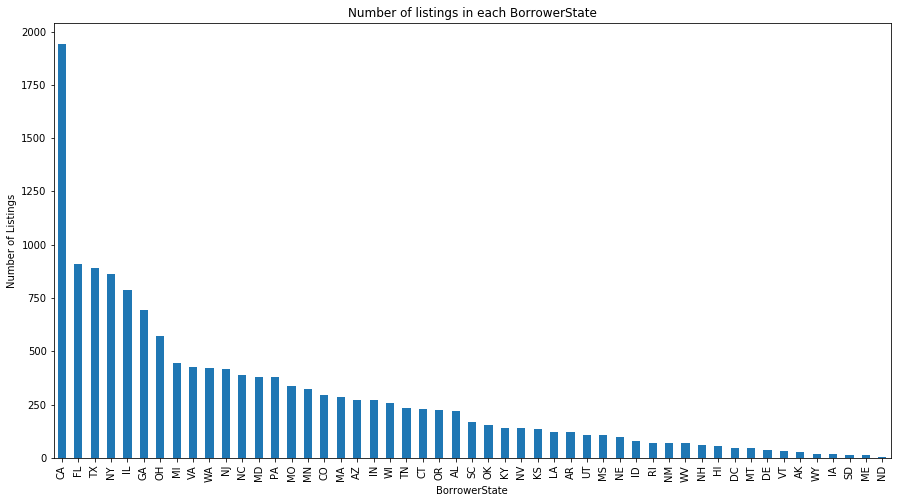

```python
#Plotting the distribution by state
plt.figure(figsize=(15, 8))
color=sb.color_palette()[0]
plt.xticks(rotation=90)
states_listings.plot(kind='bar',x=loan.BorrowerState,color=color)
plt.title('Number of listings in each BorrowerState');
plt.xlabel('BorrowerState');
plt.ylabel('Number of Listings');
#plotCountplot('BorrowerState')
```

- Based on the above plot the CA California) state,has the highest number of listings than all of other states. Where WY,IA,SD,ME,ND ranks on the lowest end.

### 3. What is the distribution of listings according Occupation.

```python
occ_counts=loan.Occupation.value_counts()
```

```
Text(0.5,1,'Occupation Distribution')
```

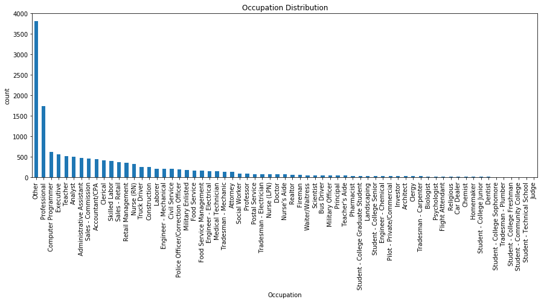

```python
col=sb.color_palette()[0]
plt.figure(figsize=(15,5))
occ_counts.plot(kind='bar',x=loan.Occupation,color=col)
plt.ylabel('count')
plt.xlabel('Occupation')
plt.title('Occupation Distribution')
```

- With lot of data points falling under 'Other' and 'Proffesional' of which is are not clear occupations, it is not easy to identify the Occupation that is listed the most. But from the other clear Occupation we can see that Computer Programmers, excecutives,Teachers, and Analyst seems to be amongst the most listed occupations.

### 3. What is the distribution of the listings according if the lister is a home owner or not.

```python
owner_counts=loan.IsBorrowerHomeowner.value_counts()
```

```
Text(0.5,1,'IsBorrowerHomeowner Distribution')
```

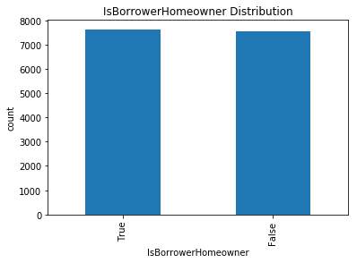

```python
col=sb.color_palette()[0]
#plt.figure(figsize=(15,5))
owner_counts.plot(kind='bar',x=loan.IsBorrowerHomeowner,color=col)
plt.ylabel('count')
plt.xlabel('IsBorrowerHomeowner')
plt.title('IsBorrowerHomeowner Distribution')
```

It is not clear as to which one has more listings, so we will use pie chart and color encoding for a more clear view

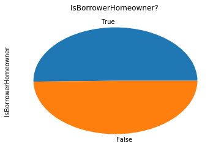

```python
loan.IsBorrowerHomeowner.value_counts().plot(kind='pie');
plt.title("IsBorrowerHomeowner? ");
plt.show();
```

- The number of listings for people who owns homes, is almost equal to the number of people who are not owning houses.

### 4. What is the distribution of the original amount that is being borrowed?

```
Text(0.5,1,'Loan Original Amount')
```

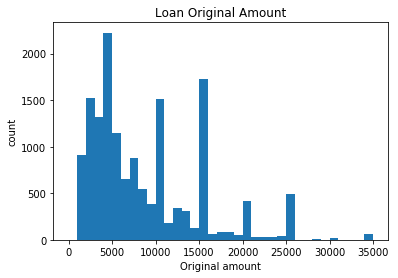

```python
bin_size=np.arange(0,loan['LoanOriginalAmount'].max()+1000,1000)
plt.hist(x='LoanOriginalAmount',data=loan,bins=bin_size);
plt.ylabel('count')
plt.xlabel('Original amount')
plt.title('Loan Original Amount')
```

- From the above plot I can simple see that lot of people are borrowing money on the range from around 1000-5000 Dollars,and there is a tail on the right showing that the data is skewed to the right since lot of data points fall on the left side of the histogram.

### 5. Distribution according to monthly repayments

```
0.0
```

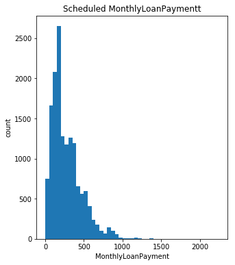

```python
plt.figure(figsize=(5,6))
bin_size=np.arange(loan['MonthlyLoanPayment'].min(),loan['MonthlyLoanPayment'].max()+50,50)
plt.hist(x='MonthlyLoanPayment',data=loan,bins=bin_size);
plt.ylabel('count')
plt.xlabel('MonthlyLoanPayment')
plt.title('Scheduled MonthlyLoanPaymentt')
#verifying the minimum monthly repayment
print(loan['MonthlyLoanPayment'].min())
```

- A huge number of people pays less than 500 Dollars a month

### Discuss the distribution(s) of your variable(s) of interest. Were there any unusual points? Did you need to perform any transformations?

> With reference to my distribution plots, I can safely conlcude that most listings are coming from the states that are recorded as states with high population. And so it makes sense to me that nore listings come from these states. Also according to occupations, most people listed their occupation as other and professional. This means it is hard to conclude on which occupation does the most listings come from. Most people are borrowing money from the 1000 dollars to 5000 dollars range.

## Bivariate Exploration

> In this section, investigate relationships between pairs of variables in your data. Make sure the variables that you cover here have been introduced in some fashion in the previous section (univariate exploration).

```python
##lists of both numerical and catagorical variable

numerical_vars=['BorrowerRate','LoanOriginalAmount', 'MonthlyLoanPayment', 'StatedMonthlyIncome','ProsperScore','Term']
catag_var=['Occupation', 'BorrowerState','IsBorrowerHomeowner']
```

### 6. What is the relationship between all numerical variables of interest and BorrowerRate

```python
# creating the scatter plot function for plotting the relationship between quantitative variables.
def scatter_plot(x,y):
    default_color = sb.color_palette()[0]
    plt.scatter(data = loan, x =x,y=y, color = default_color)
    plt.xlabel(x)
    plt.ylabel(y)
    plt.title(x + ' vs '+ y + ' relationship')
```

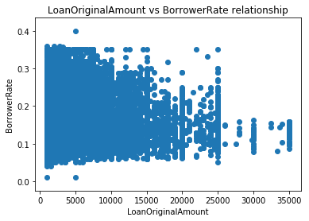

```python
scatter_plot('LoanOriginalAmount','BorrowerRate')
```

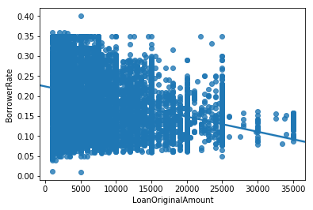

```python
#plotting the regression plot for clear visual on the relationship.
sb.regplot(x='LoanOriginalAmount',y='BorrowerRate',data=loan)
```

There is a negative correlation between Loan Original Amount and BorrowerRate

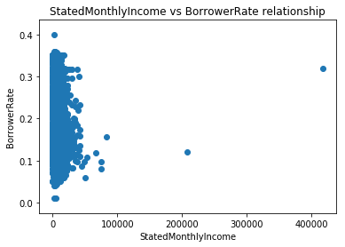

```python
scatter_plot('StatedMonthlyIncome','BorrowerRate')
```

-The income for most listings comes from the people who earns less than 100000 US Dollars but there are people who earns in the range from 200000 to around 430000

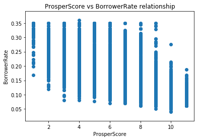

```python
scatter_plot('ProsperScore','BorrowerRate')
```

```python
loan.ProsperScore.value_counts()
```

```
4.0     1691
6.0     1615
8.0     1579
7.0     1452
5.0     1347
3.0     1043
9.0      940
2.0      730
10.0     599
11.0     181
1.0      121
Name: ProsperScore, dtype: int64
```

[figure not shown]

```python
color = sb.color_palette()[9]

sb.boxplot(data = loan, \
            x = "ProsperScore", \
            y = "BorrowerRate", \
            color = color);
plt.xticks(rotation = 90);
plt.title("Relationship between Prosper Score and Borrower rate");
```

- As the score increases the Borrower Rate decreases and that make a little bit of sense,because the are people who are in good postion according to Prosper hence they deserve the lower interest rate than those who are rated lower.

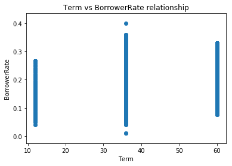

```python
scatter_plot('Term','BorrowerRate')
```

```python
loan.Term.unique()
```

```
array([36, 60, 12])
```

looks like this can be best represented using bar chart or box plot, so we will convert the data term to catagorical.

```python
loan['Term']=loan.Term.astype(str)
#confirming the dtype
type('Term')
```

```
str
```

```
Text(0.5,1,'Loan Term vs BorrowerRate')
```

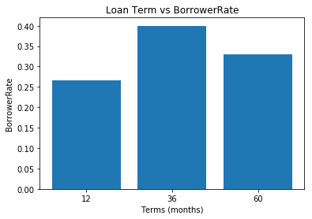

```python
#Now plotting the bar chart
plt.bar(data=loan,x='Term',height='BorrowerRate')
plt.xlabel('Terms (months)')
plt.ylabel('BorrowerRate')
plt.title('Loan Term vs BorrowerRate')
```

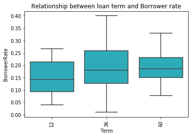

```python
color = sb.color_palette()[9]

sb.boxplot(data = loan, \
            x = "Term", \
            y = "BorrowerRate", \
            color = color);
plt.xticks(rotation = 90);
plt.title("Relationship between loan term and Borrower rate");
```

We can clearly see from the above visualizations that the term with largest maximum interest rate is 36 month term with 60 months as second largest and 12 months as the smallest.

### 7. What is the relationship between all catagorical variables of interest and BorrowerRate

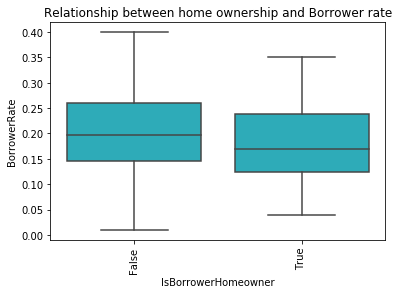

```python
# Relationship between home ownership and Borrower rate
color = sb.color_palette()[9]

sb.boxplot(data = loan, \
            x = "IsBorrowerHomeowner", \
            y = "BorrowerRate", \
            color = color);
plt.xticks(rotation = 90);
plt.title("Relationship between home ownership and Borrower rate");
```

According to the above box plot, the largest interest rate listed is found on the people who identified themselves as not the the home owners.

> Largest interest rate listed is found on the people who identified themselves as not the the home owners.

## Multivariate Exploration

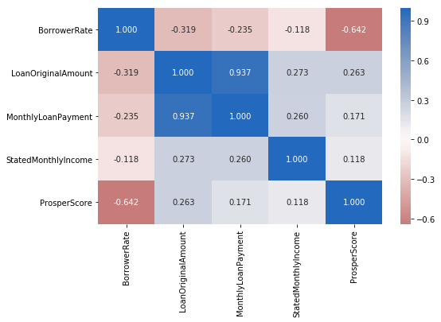

```python
# heatmap correlation between all numerical variables
plt.figure(figsize = [8, 5])
sb.heatmap(loan[numerical_vars].corr(), annot = True, fmt = '.3f',
           cmap = 'vlag_r', center = 0)
plt.show()
```

-All the numerical variables of interest have the negative correlation with the interest rate(BorrowerRate)  
-But there is a strong positive correlation among other variable outside interest rate, for example we can see a 0.937 correlation coefficient between the loan original amount and Monthly payments.  
-also some weak positive correlation among other variables for example between prosperScore and all other variables except BorrowerRate.

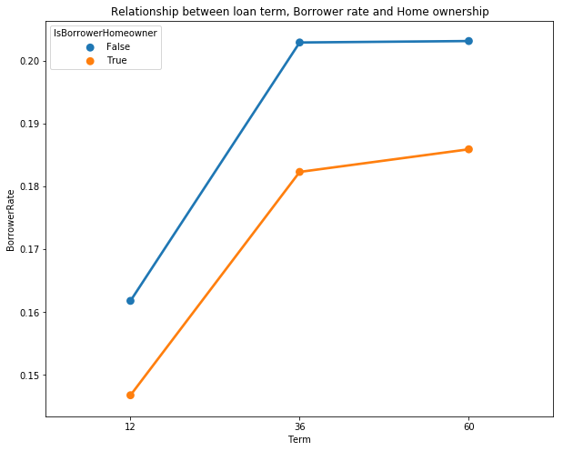

```python
## Relationship between loan term, Borrower rate and Home ownership"
plt.figure(figsize=(10,8));
sb.pointplot(data = loan, \
             x = "Term", \
             y = "BorrowerRate", \
             ci = None, \
             hue = "IsBorrowerHomeowner");
plt.title("Relationship between loan term, Borrower rate and Home ownership");
```

### Were there any interesting or surprising interactions between features?

> The most surprising relationship is the one between the prosperScore and the Borrower rate, there is a negative relationship and one might think the rating of the person should contribute on the interest rate decisions for the loan listing.